# Use eCCS to train gCCS

## Add in variant allele frequency to account for tumor content

We show that 2 * mean VAF (assuming that most tumor variants are heterozygous) still under-estimates cellularity, but it is systematic enough that it works as a proxy.

```r
# Transpose while preserving numeric types
transposed.raw <- arm.med %>%
  column_to_rownames(var = names(arm.med)[1]) %>%  # Use first column as rownames
  t() %>%
  as.data.frame() %>%
  rownames_to_column(var = "sample") %>%
  mutate(across(-sample, as.numeric)) %>%  # Ensure numeric columns
  as_tibble()

names(transposed.raw)[-1] <- paste0('arm.',names(transposed.raw)[-1])

#### get median ####

pull.median=F
if(pull.median){

  sample_list <- read.table(file.path(basedir,'/source_data/sample.list.txt'), header=F)

  first.tumor=T
  for(tumour_id in sample_list$V2){
    cat('processing ',tumour_id,'\n')
    donor_id <- sample_list$V1[sample_list$V2 == tumour_id]

    evol.file <- paste0('/Volumes/pcsi/users/fbeaudry/more.data/',tumour_id,'/pyclone/',tumour_id,'.snv.depths.txt')
    info.file <- paste0('/Volumes/pcsi/users/fbeaudry/more.data/',tumour_id,'/pyclone/',tumour_id,'.snv.info.txt')

    if(all(file.exists(evol.file) & file.exists(info.file) )){

      cat('file found\n')
      evol.data <- fread(evol.file)
      info.data <- fread(info.file)
      evol.data <-  evol.data %>% filter(mutation_id %in% info.data$mutation_id[info.data$ANNOVAR_EXONIC != 'False'])

      vaf.df <- cbind.data.frame('tumor'= tumour_id,
                                 'median.vaf' = median( evol.data$alt_counts / (evol.data$alt_counts + evol.data$ref_counts) , na.rm = T),
                                 'mean.vaf' = mean( evol.data$alt_counts / (evol.data$alt_counts + evol.data$ref_counts) , na.rm = T)
      )

      if(first.tumor){all.vaf.df <- vaf.df; first.tumor =F }else {all.vaf.df <- bind_rows(all.vaf.df, vaf.df)}

    } else {
      cat('!!file not found\n')

    }
  }

  write.table(
    all.vaf.df,
    file = file.path(basedir,'/results/median.vaf.txt'),
    row.names = FALSE, quote = FALSE, sep = "\t"
  )
} else {
  all.vaf.df <- fread(file.path(basedir,'/results/median.vaf.txt') )
}

cellularity <- fread(file.path(basedir, "/results/btc.cellularity.curated.txt"),
                     col.names = c('tumor','cellularity','ploidy'))
all.vaf.df<- full_join(cellularity, all.vaf.df, by=c('tumor'='tumor'))

cor.test(all.vaf.df$cellularity, 2*all.vaf.df$median.vaf)
```

```
##
##  Pearson's product-moment correlation
##
## data:  all.vaf.df$cellularity and 2 * all.vaf.df$median.vaf
## t = 9.5503, df = 167, p-value < 2.2e-16
## alternative hypothesis: true correlation is not equal to 0
## 95 percent confidence interval:
##  0.4870780 0.6839336
## sample estimates:
##       cor
## 0.5943369
```

```r
cor.test(all.vaf.df$cellularity, 2*all.vaf.df$mean.vaf)
```

```
##
##  Pearson's product-moment correlation
##
## data:  all.vaf.df$cellularity and 2 * all.vaf.df$mean.vaf
## t = 12.392, df = 167, p-value < 2.2e-16
## alternative hypothesis: true correlation is not equal to 0
## 95 percent confidence interval:
##  0.6043222 0.7633414
## sample estimates:
##       cor
## 0.6921394
```

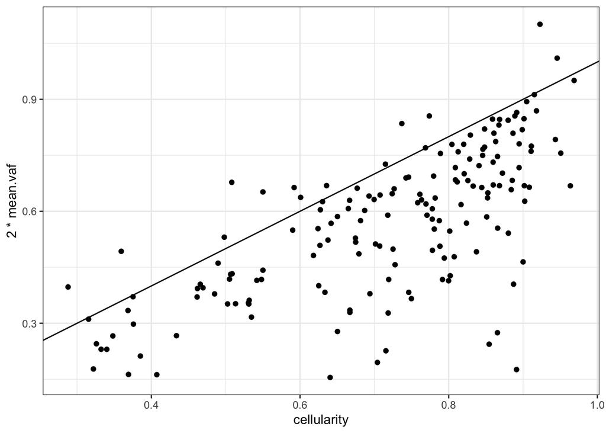

```r
ggplot(all.vaf.df, aes(x=cellularity, y=2*mean.vaf)) +
  geom_point() + theme_bw() + geom_abline(slope = 1)
```

```r
transposed.raw <- inner_join(all.vaf.df, transposed.raw, by=c('tumor'='sample'))
```

## train generalized linear model (glm)

```r
transposed <- inner_join(predicted.w.score, transposed.raw, by=c('sample'='tumor'))


refind.feature = F
retrain.model = F

if(refind.feature){


  predictor_vars <- paste0('arm.',arm.pca.contrib$arm[1:10])  # Extract the list of predictors

  formula_obj <- reformulate(termlabels = c(predictor_vars, 'cellularity'), response = "predicted_label")

  full_model <- glm(formula_obj, data = transposed , family = binomial)

  reduced_model <- step(full_model, direction = "both")

  reduced_model_summary <- summary(reduced_model)
  print(reduced_model_summary$coefficients)


}else if(retrain.model){

  train.set <- sample(transposed$sample, size=length(transposed$sample) * 0.8, replace = F)
  test.set <- transposed$sample[transposed$sample %ni% train.set]

  full_model <- glm(predicted_label ~ arm.1q + arm.4p + arm.6q + arm.9q + arm.13q + arm.18q + arm.19p + mean.vaf,
                    data = transposed %>% filter(sample %in% train.set),
                    family = binomial)


  test.data <- transposed %>% filter(sample %in% test.set)

  test.data$prob <- predict(full_model, transposed %>% filter(sample %in% test.set), type = "response")

  roc_obj <- roc(test.data$predicted_label, test.data$prob)

  cutoff <- coords(roc_obj, "best", ret = c("threshold", "sensitivity", "specificity"))

  test.data$glm_labels <- ifelse(test.data$prob > cutoff$threshold, 1, 0)
  table(test.data[,c('predicted_label', 'glm_labels')])

  saveRDS(full_model, file = file.path(basedir,'/results/cnv.model.rds'))

  model.date <- format(Sys.time(), "%y%m%d")
  saveRDS(full_model, file = paste0(basedir,'/results/cnv.model.',model.date,'rds'))

  cna.training.samples <- list('training_set'=train.set, 'test_set'=test.set)
  saveRDS(cna.training.samples, file.path(basedir,'/results/cna.training.samples.rds'))

  write.table(
    data.frame(full_model$coefficients),
    file = file.path(basedir,'/results/gCMS.weights.txt'),
    row.names = T, quote = FALSE, sep = "\t"
  )

}else{

  full_model <- readRDS(file.path(basedir,'/results/cnv.model.rds'))


  cna.training.samples <- readRDS( file.path(basedir,'/results/cna.training.samples.rds'))
  test.set <- cna.training.samples[['test_set']]



  test.data <- transposed %>% filter(sample %in% test.set)
  test.data$prob <- predict(full_model, transposed %>% filter(sample %in% test.set), type = "response")

  roc_obj <- roc(test.data$predicted_label, test.data$prob)

  cutoff <- coords(roc_obj, "best", ret = c("threshold", "sensitivity", "specificity"))

  test.data$glm_labels <- ifelse(test.data$prob > cutoff$threshold, 1, 0)
  table(test.data[,c('predicted_label', 'glm_labels')])

}
```

```
##                glm_labels
## predicted_label 0 1
##               0 9 1
##               1 2 9
```

```r
length(test.set)
```

```
## [1] 22
```

```r
summary(full_model)
```

```
##
## Call:
## glm(formula = predicted_label ~ arm.1q + arm.4p + arm.6q + arm.9q +
##     arm.13q + arm.18q + arm.19p + mean.vaf, family = binomial,
##     data = transposed %>% filter(sample %in% train.set))
##
## Coefficients:
##             Estimate Std. Error z value Pr(>|z|)
## (Intercept)  -1.9786     1.5605  -1.268  0.20484
## arm.1q        2.5171     1.0650   2.363  0.01811 *
## arm.4p        2.9577     1.4974   1.975  0.04824 *
## arm.6q       -0.9099     0.8954  -1.016  0.30955
## arm.9q       -2.1991     1.1040  -1.992  0.04637 *
## arm.13q      -1.1863     1.0946  -1.084  0.27845
## arm.18q       2.3524     0.9566   2.459  0.01393 *
## arm.19p       5.1716     1.9645   2.632  0.00848 **
## mean.vaf      1.9170     4.4764   0.428  0.66847
## ---
## Signif. codes:  0 '***' 0.001 '**' 0.01 '*' 0.05 '.' 0.1 ' ' 1
##
## (Dispersion parameter for binomial family taken to be 1)
##
##     Null deviance: 117.258  on 84  degrees of freedom
## Residual deviance:  50.711  on 76  degrees of freedom
## AIC: 68.711
##
## Number of Fisher Scoring iterations: 7
```

```r
cutoff
```

```
##   threshold sensitivity specificity
## 1 0.6918433   0.8181818         0.9
```

```r
auc(roc_obj)
```

```
## Area under the curve: 0.8727
```

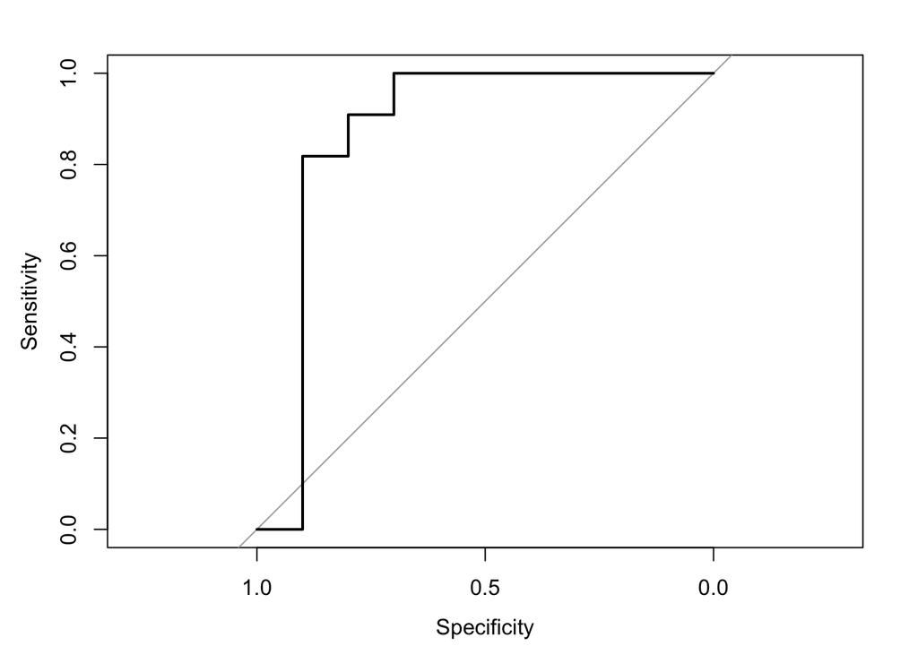

```r
plot(roc_obj)
```

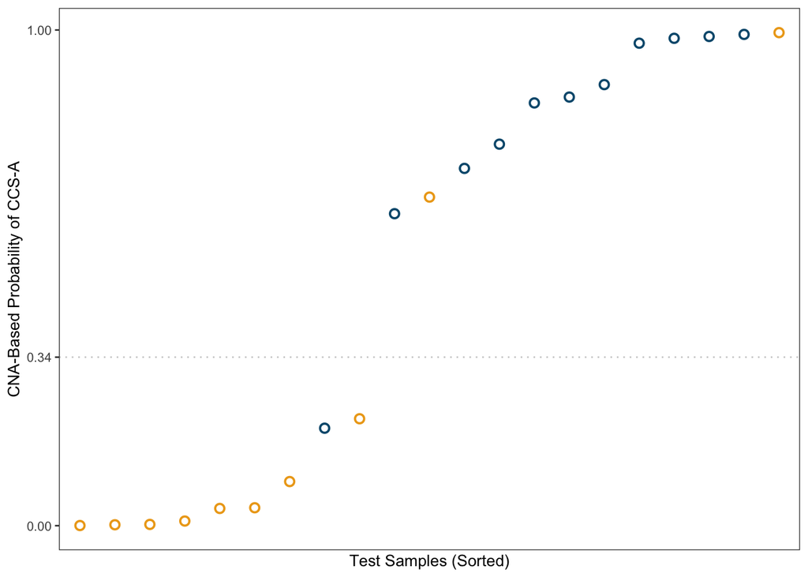

```r
cnv_prediction.test_set.plot <-
      ggplot(test.data %>% filter(!is.na(rna_class)), aes(x=reorder(sample, prob), y=prob)) +
         geom_hline(yintercept = 0.34, color='grey80', linetype='dotted')+

      #  geom_point(aes(color=factor(driver.class)),  shape=16, size=1, stroke=0.5) +
        geom_point(aes(color=factor(rna_class)),   shape=1, size=2, stroke=1) +

        theme_bw(base_size=10) +
        scale_color_manual(values = c('BAP1+'='#04597C',
                                      'TP53+'='#EDA71A',
                                      'CMS-A'="#04597C",
                                      'CMS-B'="#EDA71A"
        ),
        na.value = 'grey80')  +

        guides(color='none',fill='none')+
         theme(panel.grid = element_blank(),
               panel.background = element_blank(),
               plot.background = element_blank(),
               axis.text.x = element_blank(),
               axis.ticks.x = element_blank()
               #axis.text.x = element_text(angle = 45, hjust = 1, size=4)
               ) +
         labs(x='Test Samples (Sorted)', y='CNA-Based Probability of CCS-A',color='') +
         scale_y_continuous(breaks = c(0,0.34,1))

  cnv_prediction.test_set.plot
```

```r
ggsave(filename=paste0(basedir, "/results/fig/FIG2C.cnv_prediction.test_set.svg"), plot =
         cnv_prediction.test_set.plot
      ,   device = "svg",width = 72, height = 58, units = 'mm', dpi=72 )
```

## validate in external data

We test the model using copy number and expression data generated in [Farshidfar et al. 2017](http://dx.doi.org/10.1016/j.celrep.2017.02.033) (which you can download from [cbioportal](https://www.cbioportal.org/study/summary?id=chol_tcga_gdc)). We also add in TP53/BAP1 mutations to the plot, although in the paper narrative we haven’t established how these segregate differently by CCS yet.

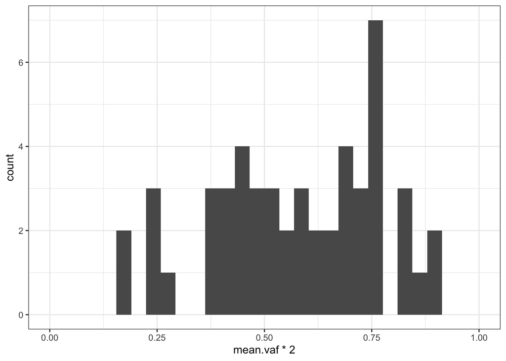

```r
far.cn <- fread(file.path(secdir,'/source_data/cbioportal/chol_tcga_gdc/data_cna_hg38.seg'))
far.cn$chrom <- paste0('chr',far.cn$chrom)

far.cn <- far.cn %>% filter(!is.na(seg.mean))

far.segmented.data <- CNSeg(far.cn)
far.segment.gene <- getRS(far.segmented.data, by="gene", imput=FALSE, XY=FALSE, geneMap=genebed, what="min")
far.segment.gene <- rs(far.segment.gene)

far.segment.gene.cyto <- inner_join(cytoBand, far.segment.gene,  by=c('Hugo_Symbol'='genename'), relationship = "many-to-many")

far.arm.med <- far.segment.gene.cyto %>%
  group_by(arm ) %>%
  summarise(across(11:ncol(far.segment.gene.cyto)-1, \(x) median(x, na.rm = TRUE)))

far.transposed.raw <- far.arm.med %>%
  column_to_rownames(var = names(far.arm.med)[1]) %>%  # Use first column as rownames
  t() %>%
  as.data.frame() %>%
  rownames_to_column(var = "sample") %>%
  mutate(across(-sample, as.numeric)) %>%  # Ensure numeric columns
  as_tibble()

names(far.transposed.raw)[-1] <- paste0('arm.',names(far.transposed.raw)[-1])

# add VAF
far.mut <- fread(file.path(secdir,'/source_data/cbioportal/chol_tcga_gdc/data_mutations.txt'))
far.mut$mean.vaf <- far.mut$t_alt_count / (far.mut$t_ref_count + far.mut$t_alt_count)

far.med.vaf <- far.mut %>%
  group_by(Tumor_Sample_Barcode ) %>%
  summarise(across(mean.vaf, \(x) mean(x, na.rm = TRUE)))

ggplot(far.med.vaf, aes(x=mean.vaf * 2)) + geom_histogram() + theme_bw() + xlim(0,1)
```

```r
far.transposed.raw <- inner_join(far.med.vaf, far.transposed.raw, by=c('Tumor_Sample_Barcode'='sample'))

# predict
far.transposed.raw$prob <- predict(full_model, far.transposed.raw , type = "response")

## compare to RNA class
far.mrna <- fread(file.path(secdir,'/source_data/cbioportal/chol_tcga_gdc/data_mrna_seq_tpm.txt'))
gene_info <- fread(file.path(secdir,'/source_data/cbioportal/gene_info.txt'))
far.mrna <- inner_join(gene_info, far.mrna, by=c('ENTREZID'='Entrez_Gene_Id'))

far.mrna.mat <- as.matrix(far.mrna[,-c(1:2)])
rownames(far.mrna.mat) <- far.mrna$Hugo_Symbol

classifier <- readRDS(file.path(basedir,'/results/tps.classifier.rds'))
far.predicted.w.score <- predict_TSP_with_confidence(tsp_classifier=classifier, tpm_matrix=far.mrna.mat, confidence_cutoff = 0.8 )

far.predicted.w.score$Tumor_Sample_Barcode <- rownames(far.predicted.w.score)

## pull common muts

far.driver <- far.mut %>% filter(Hugo_Symbol %in% c('BAP1','FGFR2','IDH1','TP53','SMAD4')) %>%
  dplyr::select(Tumor_Sample_Barcode, Hugo_Symbol) %>%
  dcast(Tumor_Sample_Barcode ~ Hugo_Symbol, value.var = 'Hugo_Symbol')

far.driver[is.na(far.driver)] <- 0

far.driver.cms.cnv <- full_join(far.driver,far.predicted.w.score, by=c('Tumor_Sample_Barcode'='Tumor_Sample_Barcode') ) %>%
  full_join(far.transposed.raw, by=c('Tumor_Sample_Barcode'='Tumor_Sample_Barcode'))

far.driver.cms.cnv$sample <- factor(far.driver.cms.cnv$Tumor_Sample_Barcode,
                                    levels=far.driver.cms.cnv$Tumor_Sample_Barcode[order(far.driver.cms.cnv$prob)])

far.roc_obj <- roc(far.driver.cms.cnv$predicted_label, far.driver.cms.cnv$prob)
auc(far.roc_obj)
```

```
## Area under the curve: 0.9487
```

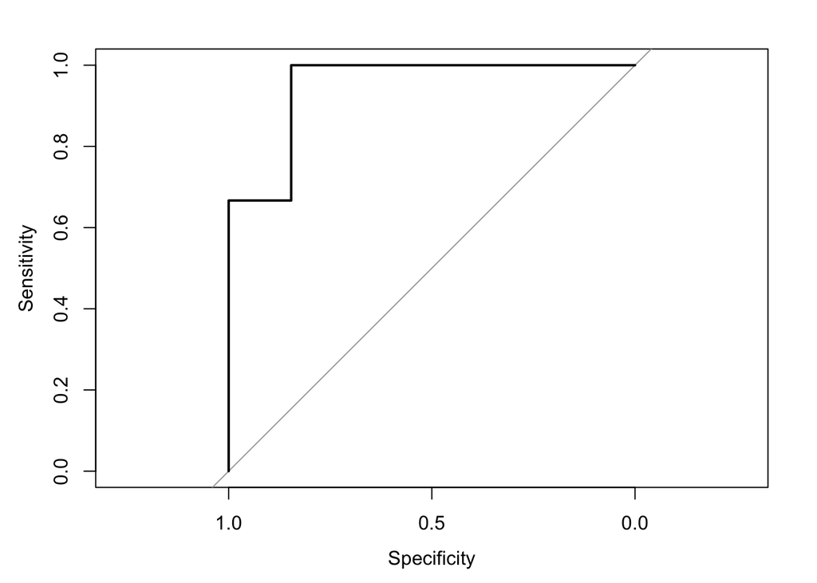

```r
plot(far.roc_obj)
```

```r
coords(far.roc_obj, 0.34, ret = c("threshold", "sensitivity", "specificity"))
```

```
##   threshold sensitivity specificity
## 1      0.34           1   0.8461538
```

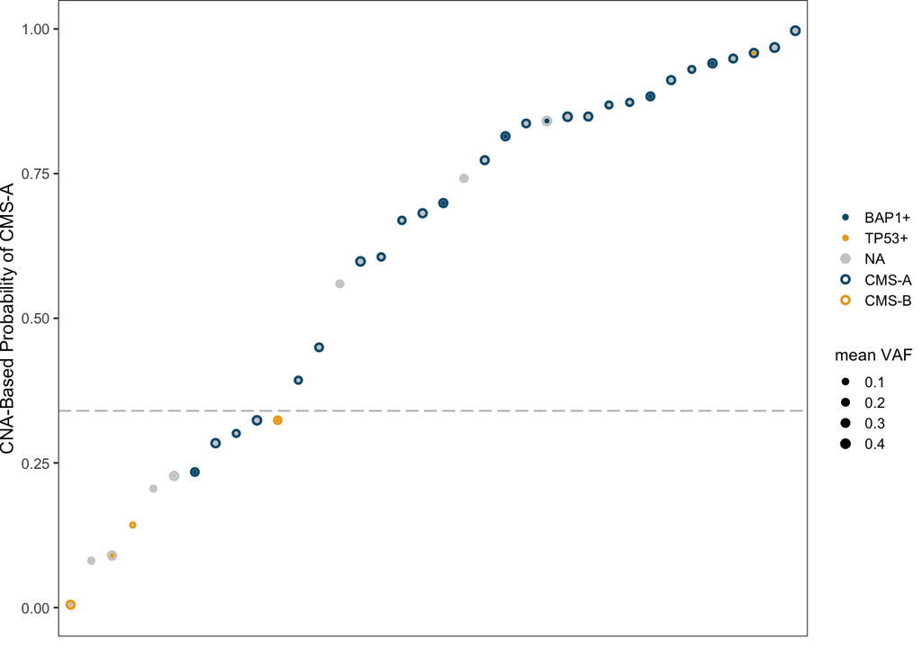

```r
far.driver.cms.cnv$glm_labels <- ifelse(far.driver.cms.cnv$prob > cutoff$threshold, 'gCMS-A', 'gCMS-B')

far.driver.cms.cnv$driver.class <- NA
far.driver.cms.cnv$driver.class[far.driver.cms.cnv$BAP1 == 'BAP1'] <- 'BAP1+'
far.driver.cms.cnv$driver.class[far.driver.cms.cnv$TP53 == 'TP53'] <- 'TP53+'

cnv_prediction.farshidfar.plot <-
ggplot(far.driver.cms.cnv   %>% filter(!is.na(prob)), aes(x=reorder(Tumor_Sample_Barcode, prob), y=prob)) +

  geom_hline(yintercept = 0.34, color='grey', linetype='longdash')+

  geom_point(aes(size=mean.vaf*0.5, color=factor(driver.class)),  shape=16,  stroke=0.5) +
  geom_point(aes( size=mean.vaf,color=factor(rna_class)),   shape=1, stroke=1) +
  scale_size(range = c(0.1,1.5))  +

  theme_bw(base_size=10) +
  scale_color_manual(values = c('BAP1+'='#04597C',
                                'TP53+'='#EDA71A',
                                'CMS-A'="#04597C",
                                'CMS-B'="#EDA71A"
  ),
  na.value = 'grey80')  +
  theme(panel.grid = element_blank(),
        plot.margin = unit(c(0, 0, 0, 0), "mm"),
        legend.key.size = unit(0.4, "cm"),   # Shrinks the legend keys (symbols)
        legend.text = element_text(size = 8), # Shrinks the text for legend items
        legend.title = element_text(size = 9) ,# Shrinks the legend title

        panel.background = element_blank(),
        plot.background = element_blank(),
        axis.ticks.x = element_blank(),
        axis.text.x = element_blank()) +
  ylim(0,1)+
  labs(x='', y='CNA-Based Probability of CMS-A',color='', size='mean VAF' )
cnv_prediction.farshidfar.plot
```

```r
write.table(
  far.driver.cms.cnv %>% dplyr::select(Tumor_Sample_Barcode, rna_class, confidence, glm_labels, prob, driver.class),
  file = file.path(basedir,'/results/tcga.cms.txt'),
  row.names = FALSE, quote = FALSE, sep = "\t"
)
```